# S4_P4 Informe

UTEC - Universidad de Ingeniería y Tecnología

### **Estadística y Probabilidades**

#### **Las herramientas digitales de comunicación empleadas en UTEC**

**I. Introducción**

Con la llegada inesperada de la pandemia del Covid-19, muchas actividades humanas han cambiado radicalmente alrededor del mundo. Sin lugar a dudas, la educación es una de las actividades que se ha visto afectada por la pandemia, puesto que en prácticamente todos los países del mundo las clases presenciales fueron suspendidas y reemplazadas por clases a distancia, o también llamadas clases virtuales. Consecuentemente, la forma de comunicación que se entablaba entre profesores y alumnos también cambió de manera radical. Se pasó de las numerosas consultas en los pasillos a los incontables mensajes de texto en el móvil o el correo electrónico, de los seminarios en los auditorios a las reuniones masivas en plataformas tecnológicas audiovisuales, así como otros ejemplos relacionados a este contexto que explican las formas en que la interacción entre profesores y alumnos se vio modificada. Bajo estas circunstancias, los medios de comunicación virtuales obtuvieron un protagonismo sin precedentes en los sistemas educativos. No obstante, esto conlleva a discusiones como: ¿Los alumnos se sienten cómodo con el uso masivo de medios digitales? ¿Los profesores lograron adaptarse eficazmente a esta nueva coyuntura de trabajo? ¿Cuál es la percepción acerca de esta forma de comunicación? A través de este estudio queremos saber con cuál de todas las herramientas de comunicación empleadas actualmente, los alumnos de UTEC se sienten más cómodos al recibir e intercambias información con los profesores y la comunidad UTEC.

**Importancia**

El estudio presentado a continuación recolectará data relevante sobre la percepción estudiantil UTEC acerca de los medios virtuales de comunicación. Este tema es muy importante, ya que los estudiantes y profesores pertenecientes a la comunidad UTEC buscan conocer cuál es el medio más óptimo y eficiente para el intercambio y comunicación de información entre ellos. Con el resultado del estudio, pensamos que se puede llegar conocer los medios de comunicación más agradables que ofrecen una buena experiencia en el ámbito educativo y, de este modo, demostrar qué herramienta de comunicación virtual debería ser más empleada en los posteriores cursos de UTEC.

**Justificación**

El estudio aportará conclusiones importantes acerca del desarrollo académico de UTEC a lo largo de estos ciclos virtuales, específicamente de la comunicación virtual entre profesores y alumnos. Además, se conseguirá ayudar al equipo TI de UTEC a ofrecer mejores experiencias de aprendizaje puesto que, al conocer las preferencias de los estudiantes, su opinión podrá ser tomada en consideración en las próximas formas de comunicación virtual UTEC, consiguiendo alternativas más personalizadas y orientadas al bienestar estudiantil.

**Factibilidad**

Consideramos que nuestro estudio es factible, debido a que nuestros datos se están recolectando a través de encuestas elaboradas por nosotros. Asimismo, contamos con la colaboración de los estudiantes de UTEC, que nos ayudará a realizar un análisis adecuado para el estudio y nos permitirá elaborar conclusiones justificadas respecto a él. Utilizaremos un diagrama de Gantt para poder tener una organización clara sobre los plazos de las tareas que debemos realizar para conseguir que nuestro proyecto cumpla con los requerimientos solicitados.

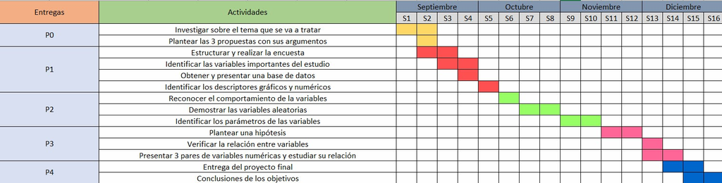

**II. Objetivos**

- *Objetivo General*: Determinar con cuál de todas las herramienta empleadas actualmente de comunicación, los alumnos de UTEC se sienten más cómodos al recibir información sobre los cursos que llevan o noticias de la universidad.
- *Pregunta General*: ¿Cuál es la herramienta digital que los alumnos consideran que permite una mejor comunicación en la comunidad UTEC?

**III. Marco Teórico**

- *Población Objetivo*: Para este estudio se han evaluado estudiantes de UTEC.
- *Tipo de Muestreo*: Muestreo aleatorio simple, puesto que solo consideramos estudiantes al azar de UTEC.
- *Unidades Muestrales*: Se cuenta con 237 estudiantes encuestados hasta el momento.
- *Interesados*: Estudiantes y los profesores de UTEC, para conocer los factores que influyen en que esta sea la plataforma favorita de los estudiantes. Esto demostrará cuál debería ser la herramienta más empleada en los cursos de UTEC, o al menos cual es la que los profesores deberían tener en cuenta los próximos ciclos.

**Variables**

- **Código**
- **Edad**
- **Carrera**
- **Ciclo**
- **PromNotas**: Promedio ponderado de su último ciclo académico (utilice punto como separador decimal). Ej: 15.94
- **PromCursos**: Promedio estimado de cursos que llevas por ciclo académico. Ej: 6.5
- **MejoraMC**: ¿Consideras que los medios de comunicación de UTEC han mejorado con la llegada de la pandemia? (Sí / No)
- **EficienciaMC**: ¿Qué tan eficiente crees que son los medios de comunicación empleados en la difusión de anuncios de los cursos? (Medios de comunicación son los elegido por el profesor del curso o los asistentes).
- **ProfesoresMC**: ¿Qué medios de comunicación han empleado algunos profesores o asistentes para enviar anuncios sobre el curso? (Marcar todas las que han empleado)
- **MaxMC**: ¿Cuál es el medio de comunicación que más usas?
- **Max2MC**: ¿Cuál es el segundo medio de comunicación que más usas?
- **ComodidadMC**: ¿Con qué medio de comunicación (elegido por el profesor del curso o asistente) te sientes más cómodo?
- **NoComodidadMC**: ¿Cuál es el medio de comunicación con el que sientes que no puedes tener una comunicación directa y asertiva con los profesores de tus cursos?
- **SilenciadosMC**: Seleccione el medio de comunicación en el que tenga más chats silenciados.
- **SaturadoMC**: ¿Cuál es el medio de comunicación que tienes más saturado?
- **SatisfechoMC**: ¿Qué tan satisfecho te sientes con los siguientes medios de comunicación con respecto a la eficiencia de transmisión de las noticias de los cursos? (0 representa que no lo he usado, 1 representa poco satisfecho y 5 muy satisfecho).
- **PromHorasMC**: Cuántas horas al día en promedio utilizas medios de comunicación relacionados con noticias de la universidad. Ej: 4.5
- **TiempoMC**: ¿Cuántas horas al día utilizas las siguientes aplicaciones?
- **MasDominioMC**: ¿Cuál es el medio de difusión que más dominas?
- **MenosDominioMC**: ¿Cuál es el medio de difusión que menos dominas?
- **LeeAnuncio**:¿Siempre has leído los anuncios de tus cursos a tiempo?
- **Conectividad**: ¿Cómo es tu conexión a Internet?
- **Actividades**: ¿Cuáles de las siguientes actividades realizas?
- **VJuegos**: ¿Juegas videojuegos?

**Tabla - Tipos de Variables**

| Variables | Tipo |
| --- | --- |
| Código | Categórica → Ordinal |
| Edad | Numérica → Discreta |
| Carrera | Categórica → Nominal |
| Ciclo | Categórica → Ordinal |
| PromNotas | Numérica → Continua |
| PromCursos | Numérica → Continua |
| MejoraMC | Categórica → Nominal |
| EficienciaMC | Categórica → Ordinal |
| ProfesoresMC | Categórica → Nominal |
| MaxMC | Categórica → Nominal |
| Max2MC | Categórica → Nominal |
| ComodidadMC | Categórica → Nominal |
| NoComodidadMC | Categórica → Nominal |
| SilenciadosMC | Categórica → Nominal |
| SaturadoMC | Categórica → Nominal |
| SatisfechoMC | Categórica → Nominal |
| PromHorasMC | Numérica → Continua |
| TiempoMC | Numérica → Discreta |
| MasDominioMC | Categórica→ Nominal |
| MenosDominioMC | Categórica → Nominal |
| LeeAnuncio | Categórica → Nominal |
| Conectividad | Categórica → Ordinal |
| Actividades | Categórica → Nominal |
| VJuegos | Categórica → Nominal |

**IV. Procesamiento de Datos**

En primer lugar, instalamos las librerías para garantizar una correcta ejecución del proyecto:

```r
lista.paquetes <- c("readr", "dplyr","corrplot","PerformanceAnalytics")
nuevos.paquetes <- lista.paquetes[!(lista.paquetes %in% installed.packages()[,"Package"])]
if(length(nuevos.paquetes)) install.packages(nuevos.paquetes)
```

Cargamos las librerías:

```r
library(readr)
library(dplyr)
```

```r
library(corrplot)
library(PerformanceAnalytics)
```

Cargamos los datos de nuestro estudio en un dataframe inicial llamado DF:

```r
DF<-read_csv("Respuestas.csv");
```

Observamos los nombres de los encabezados:

```r
names(DF)
```

```
##  [1] "Marca temporal"
##  [2] "Dirección de correo electrónico"
##  [3] "Código del alumno"
##  [4] "Edad:"
##  [5] "Carrera a la que pertenece"
##  [6] "Ciclo académico que cursas"
##  [7] "Promedio ponderado de su último ciclo académico (utilice punto como separador decimal). Ej: 15.94"
##  [8] "Promedio estimado de cursos que llevas por ciclo académico. Ej: 6.5"
##  [9] "¿Consideras que los medios de comunicación de UTEC han mejorado con la llegada de la pandemia?"
## [10] "¿Qué tan eficiente crees que son los medios de comunicación empleados en la difusión de anuncios de los cursos? (Medios de comunicación son los elegido por el profesor del curso o los asistentes)"
## [11] "¿Qué medios de comunicación han empleado algunos profesores o asistentes para enviar anuncios sobre el curso? (Marcar todas las que han empleado)"
## [12] "¿Cuál es el medio de comunicación que más usas?"
## [13] "¿Cuál es el segundo medio de comunicación que más usas?"
## [14] "¿Con qué medio de comunicación (elegido por el profesor del curso o asistente) te sientes más cómodo?"
## [15] "¿Cuál es el medio de comunicación con el que sientes que no puedes tener una comunicación directa y asertiva con los profesores de tus cursos?"
```

[output cut: 21 more lines]

Renombrados las variables para tener un manejo mas práctico de ellas:

```r
colnames(DF)[3:36]<-c("Codigo","Edad","Carrera","Ciclo","PromNotas","PromCursos","MejoraMC","EficienciaMC","ProfesoresMC","MaxMC","Max2MC","ComodidadMC","NoComodidadMC","SilenciadosMC","SaturadoMC","SatisfechoMCW", "SatisfechoMCT", "SatisfechoMCD", "SatisfechoMCG", "SatisfechoMCC", "SatisfechoMCF","PromHorasMC", "TiempoMCW", "TiempoMCT", "TiempoMCD", "TiempoMCG", "TiempoMCC", "TiempoMCF", "MasDominioMC","MenosDominioMC","LeeAnuncio","Conectividad", "Actividades","VJuegos")
```

Ahora, nuestro dataframe esta actualizado y cuenta con los nombres abreviados de las variables que vamos a emplear en nuestro estudio.

**Limpieza de datos**

En nuestros datos recolectados no existe los datos faltantes (NA); por tal motivo, no se realizará una limpieza de NA, ya que se colocaron como obligatorias todas las preguntas del Google Forms.

En la limpieza de nuestro dataframe se eliminarán los datos que no vamos a emplear, es decir, aquellos datos predeterminados de la herramienta Google Forms. Estas son **“Marca temporal”** y **“Correo electrónico”**. De esta manera, obtenemos el dataframe final:

En el dataframe final (Dfinal) guardaremos los datos que se van a emplear en el estudio, por tal motivo, seleccionamos desde el código hasta actividades.

```r
DFinal <- select(DF,Codigo:VJuegos)
```

Mostramos las 6 primeras observaciones:

```r
head(DFinal, n=6)
```

| Codigo | Edad | Carrera | Ciclo | PromNotas | PromCursos | MejoraMC | EficienciaMC | ProfesoresMC | MaxMC | Max2MC | ComodidadMC | NoComodidadMC | SilenciadosMC | SaturadoMC | SatisfechoMCW | SatisfechoMCT | SatisfechoMCD | SatisfechoMCG | SatisfechoMCC | SatisfechoMCF | PromHorasMC | TiempoMCW | TiempoMCT | TiempoMCD | TiempoMCG | TiempoMCC | TiempoMCF | MasDominioMC | MenosDominioMC | … |
| --- | --- | --- | --- | --- | --- | --- | --- | --- | --- | --- | --- | --- | --- | --- | --- | --- | --- | --- | --- | --- | --- | --- | --- | --- | --- | --- | --- | --- | --- | --- |
| 202110627 | 17 | Ing. Ambiental | 2 | 15.50 | 7 | No | 4 | WhatsApp, Telegram, Discord | Telegram | WhatsApp | Telegram | WhatsApp | Discord | Discord | 4 | 5 | 3 | 3 | 3 | 0 | 4 | 6.0 | 1 | 2 | 1 | 3 | 3 | WhatsApp | Discord | … |
| 202010375 | 18 | Ing. Ambiental | 4 | 15.80 | 7 | Sí | 4 | WhatsApp, Telegram, Discord, Gmail, Canvas, Facebook | Discord | Telegram | Telegram | Canvas | WhatsApp | WhatsApp | 4 | 5 | 2 | 4 | 1 | 3 | 5 | 6.0 | 1 | 2 | 1 | 1 | 2 | WhatsApp | Canvas | … |
| 202010375 | 18 | Ing. Ambiental | 4 | 17.00 | 6 | No | 4 | WhatsApp, Telegram, Discord, Gmail, Canvas, Facebook | WhatsApp | Gmail | Telegram | Canvas | Discord | WhatsApp | 3 | 5 | 1 | 4 | 0 | 2 | 3 | 5.0 | 3 | 1 | 4 | 0 | 2 | WhatsApp | Canvas | … |
| 202020151 | 20 | Ing. Mecatrónica | 3 | 14.23 | 7 | No | 4 | WhatsApp, Telegram, Discord, Gmail, Canvas, Facebook | WhatsApp | Discord | WhatsApp | Gmail | WhatsApp | WhatsApp | 5 | 2 | 2 | 1 | 1 | 1 | 3 | 8.0 | 6 | 5 | 4 | 5 | 5 | WhatsApp | Discord | … |
| 202025698 | 20 | Ing. Energía | 4 | 16.85 | 6 | Sí | 4 | WhatsApp, Telegram, Gmail, Canvas, Facebook | WhatsApp | Discord | Canvas | Discord | WhatsApp | Telegram | 3 | 3 | 3 | 5 | 2 | 4 | 5 | 6.2 | 5 | 1 | 1 | 2 | 1 | WhatsApp | Canvas | … |
| 202010102 | 18 | Ing. Electrónica | 4 | 16.00 | 6 | Sí | 2 | WhatsApp, Telegram, Discord, Gmail, Canvas, Facebook | WhatsApp | Telegram | Discord | Facebook | Telegram | Gmail | 4 | 4 | 5 | 3 | 2 | 0 | 4 | 4.0 | 0 | 3 | 1 | 4 | 4 | WhatsApp | Canvas | … |

Los datos obtenidos se dividirán en dos “sub” dataframes, uno para los que consideran que la comunicación ha mejorado y otro para los que creen que la comunicación no ha mejorado. Para realizar esa división se utilizará filter(), con el cual filtraremos las variables que vamos a emplear.

- DFS es el dataframe de los que consideran que la comunicación en UTEC ha mejorado.

```r
DFS <- filter(DFinal, DFinal$MejoraMC == "Sí")
```

- DFN es el dataframe de los que consideran que la comunicación en UTEC no ha mejorado.

```r
DFN <- filter(DFinal, DFinal$MejoraMC == "No")
```

- DFSJV es el dataframe de los que sí juegan videojuegos y DFNJV es de los que no juegas videojuegos.

```r
DFSJV <- filter(DFinal, DFinal$VJuegos == "Sí")
DFNJV <- filter(DFinal, DFinal$VJuegos == "No")
```

- DFB y DFA son los dataframes de las notas, las cuales hemos considerado de menor de 15 nota baja y mayor de 15 nota alta

```r
DFB <- filter(DFinal, DFinal$PromNotas <= "15")
DFA <- filter(DFinal, DFinal$PromNotas >= "15")
```

Con nuestros dataframes completos y ordenados se pasará a realizar los descriptores.

**V. Analizando nuestra muestra**

Para nuestro estudio emplearemos una confianza del 95%, con el fin de asegurar que la media de la población (verdadero parámetro) se encuentre en nuestro intervalo. Se hace una aproximación de la media de la población con una muestra (nuestros datos) y verificamos si está en el intervalo de confianza para obtener un estudio relevante y representativo.

```r
#Confianza de 95 %
#95% = 0.95
#alfa = Significancia
alfa <- 0.05 #alfa = 1-0.95
alfa.2 <- 0.025 #alfa/2
#su complemento es = 0.975
```

Función para redondear a centésimas.

```r
r <- function(x){
  return(round(x, digits = 2))
}
```

Para hallar $Z_{\frac{\alpha}{2}}$

```r
r(qnorm(0.975,0,1))
```

```
## [1] 1.96
```

```r
r(qnorm(0.025,0,1))
```

```
## [1] -1.96
```

$n =(1.96^2 * 2500)/ (0.122)^2 *(N-1)*1.96^2 )$

e: margen de error

z: la confianza(z = 1.96)

[output not shown]

**VI. Análisis descriptivo**

Después de obtener nuestro z o zcrítico, realizamos un análisis de los descriptores gráficos y numéricos más relevantes para nuestro estudio.

*Analizando el promedio de horas en los medios de comunicación:*

Para fines del estudio, consideramos que es importante tomar en cuenta el promedio de horas que los alumnos invierten en todos los medios de comunicación. Para ello, vamos a dividir el dataframe original en versiones con menos observaciones, pero que contengan algunas características en común que serán útiles más adelante para realizar hipótesis.

- Se divide el dataframe final (DFinal) en dos dataframes. El primero contendrá las observaciones de aquellos estudiantes que siempre leen los anuncios de sus cursos a tiempo y, por otro lado, el segundo contendrá las observaciones de aquellos que en ocasiones no leen sus anuncios a tiempo.

```r
DF.lee.anuncio <- DFinal[DFinal$LeeAnuncio == "Sí", ]
evil.DF.lee.anuncio <- DFinal[DFinal$LeeAnuncio == "No", ]
```

- Con el fin de hallar los intervalos de confianza, primero haremos uso del t.test, que nos indicará los límites inferior y superior del intervalo de confianza.

[output not shown]

- Además, emplearemos el método aprendido en clase para calcular estos límites:

```r
n<-nrow(DF.lee.anuncio)
media <-mean(DF.lee.anuncio$PromHorasMC)
desv  <-sd(DF.lee.anuncio$PromHorasMC)
error.est<-desv/sqrt(n)
margen.error<-qnorm(1-alfa.2, 0, 1)*error.est
margen.error
```

```
## [1] 0.4059829
```

- Hallando los límites del intervalo de confianza:

```r
lim.inf<-media-margen.error
lim.inf
```

```
## [1] 3.419599
```

```r
lim.sup<-media+margen.error
lim.sup
```

```
## [1] 4.231564
```

Crearemos este histograma que representará el promedio de horas de aquellos estudiantes que sí leen sus anuncios a tiempo.

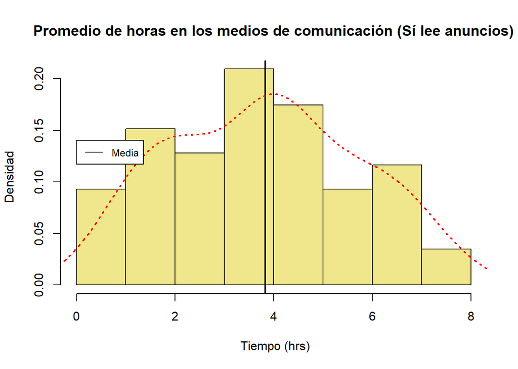

```r
hist(DF.lee.anuncio$PromHorasMC
     , breaks=9
     , freq = FALSE
     , main="Promedio de horas en los medios de comunicación (Sí lee anuncios)"
     , xlab=" Tiempo (hrs)"
     , ylab = "Densidad", col = "khaki")

abline(v = mean(DF.lee.anuncio$PromHorasMC),col = "black",lwd = 2)

lines(density(na.omit(DF.lee.anuncio$PromHorasMC))
      , lty="dotted"
      , lwd=2
      , col="red")

legend(0, 0.14
       , legend=c("Media")
       , col=c("black")
       , lty=1, cex=0.8)
```

**Observaciones de la variable PromTiempoMC:**

- En este histograma podemos observar que existe una acumulación de densidad dentro del intervalo de [3-5]. Además, existe un intervalo que contiene la menor acumulación de densidad, que es el último intervalo [7-8]. Por último, podemos observar que la media se encuentra dentro del los intervalos que contienen la mayor densidad.

*Analizando el promedio académico:*

Nuestra variable promedio académico (numérica continua) es relevante para el estudio porque está relacionada con los medios de comunicación. De esta manera, conforme el estudiante se adecue mejor al uso de los medios de comunicación, puede alcanzar mejores resultados. Por ello, consideramos que si los alumnos pueden obtener mejores calificaciones este es influenciado por el medio de comunicación que se utilicen en los diferentes cursos, así es como encontramos una aparente relación en las variables promedio ponderado y tiempo promedio de uso de los diversos medios de comunicación.

Tenemos los siguientes descriptores gráficos y numéricos sobre el promedio de notas de los estudiantes encuestados.

- Promedio general de la variable promedio de notas de los alumnos durante el ciclo pasado

```r
mean(DFinal$PromNotas)
```

```
## [1] 15.56063
```

- Utilizaremos un boxplot con la finalidad de tener una idea sobre la dispersión de nuestras observaciones de la variable promedio de notas.

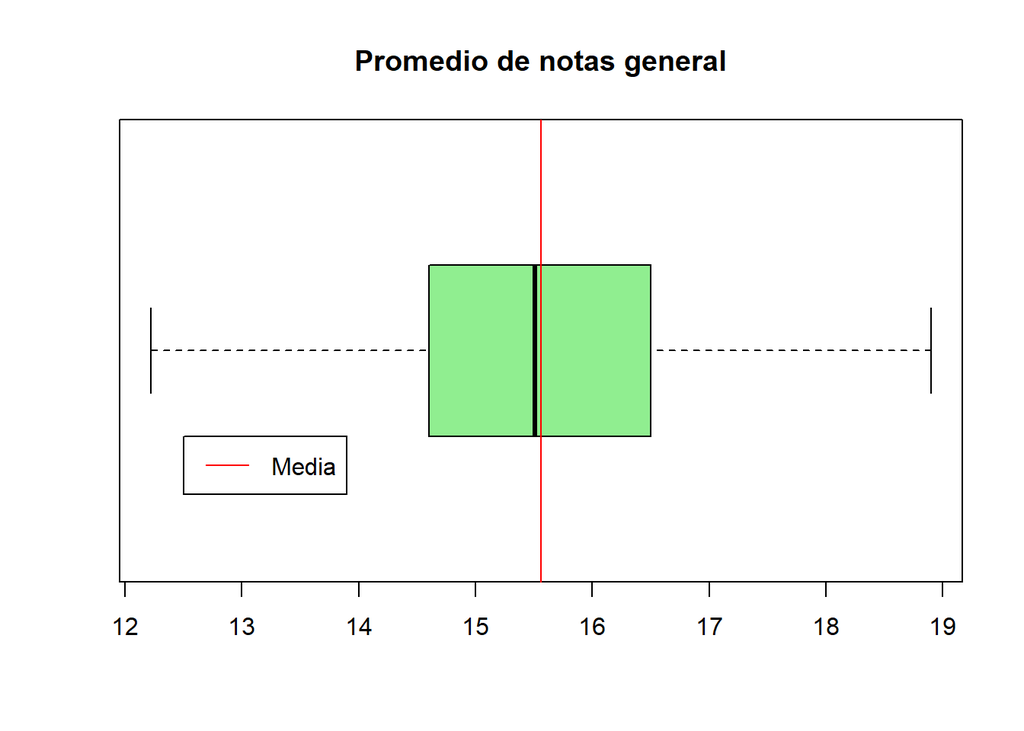

```r
boxplot(DFinal$PromNotas,
        col="lightgreen",
        main="Promedio de notas general",
        horizontal = TRUE
        )

abline(v = mean(DFinal$PromNotas), col = "red")
legend(12.5, 0.8 ,"Media", col = "red", lty=1)
```

Con el fin de llegar a nuestro objetivo, decidimos relacionar la variable promedio académico con la variable juega videojuegos; además, la relacionaremos con tiempo de uso de Discord mayor a 0, esto fue para asegurarnos que trabajamos con alumnos que sí emplean Discord. Esto se debe a que, como podemos observar en el siguiente boxplot (Boxplot de tiempo en Discord), las personas que juegan videojuegos emplean más Discord que aquellos que no juegan videojuegos, esto nos servirá para formular nuestras hipótesis más adelante.

- En el siguiente gráfico tenemos un boxplot de tiempo dedicado a Discord, para esto empleamos 2 dataframes creados previamente. Los dataframes son DFSJV y DFNJV.

DFSJV = sí juega videojuegos

DFNJV = no juega videojuegos

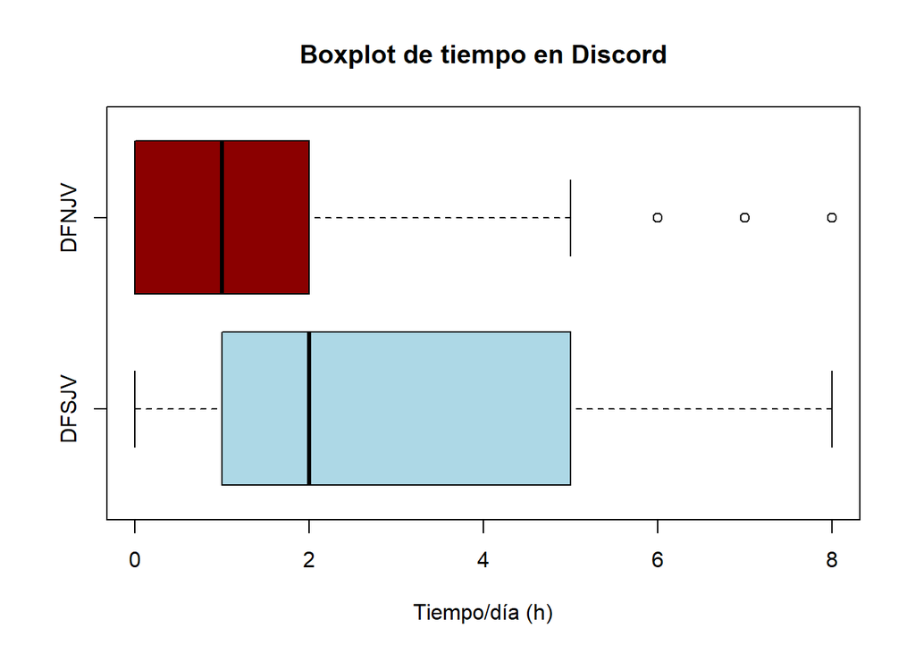

```r
boxplot(DFSJV$TiempoMCD,
        DFNJV$TiempoMCD,
        main = "Boxplot de tiempo en Discord",
        names = c("DFSJV","DFNJV"),
        xlab = "Tiempo/día (h)",
        col = c("lightblue","darkred"),
        horizontal = TRUE)
```

```r
DFJuega.VJ <- DFinal[DFinal$VJuegos == "Sí" & DFinal$TiempoMCD > 0, ]
```

Ahora, con el nuevo dataframe hallaremos los intervalos de confianza del promedio de notas de los estudiantes que sí juegan videojuegos y utilizan Discord.

```r
n4<-nrow(DFJuega.VJ)
media4<-mean(DFJuega.VJ$PromNotas)
desv4<-sd(DFJuega.VJ$PromNotas)
error.est4<-desv4/sqrt(n4)
margen.error4<-qnorm(1-alfa.2, 0, 1)*error.est4
margen.error4
```

```
## [1] 0.2326488
```

Hallando los límites del intervalo de confianza:

```r
lim.inf4<-media4-margen.error4
lim.inf4
```

```
## [1] 15.47158
```

```r
lim.sup4<-media4+margen.error4
lim.sup4
```

```
## [1] 15.93687
```

Se creará nuestro histograma del promedio de notas de los estudiantes que sí juegan videojuegos y utilizan Discord.

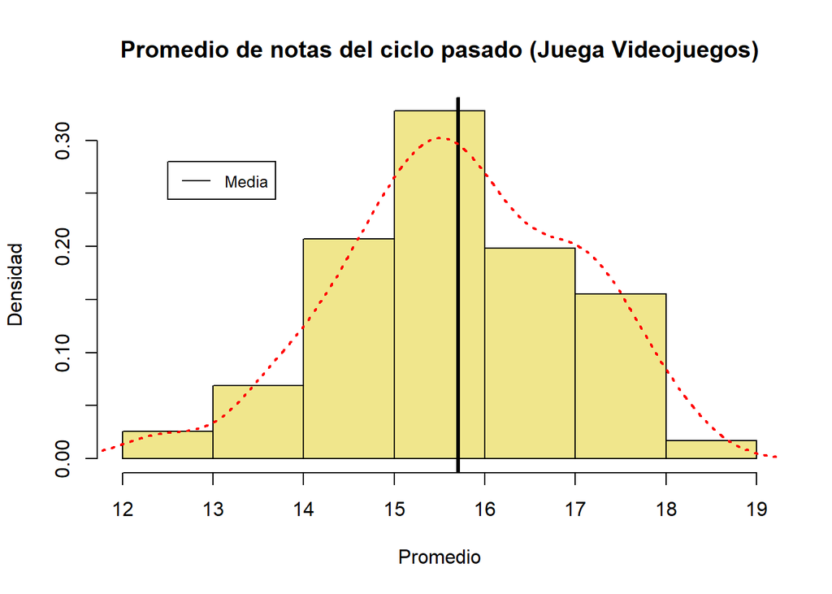

```r
# Generate the plot
hist(DFJuega.VJ$PromNotas
     , breaks=8
     , freq = FALSE
     , main="Promedio de notas del ciclo pasado (Juega Videojuegos)"
     , xlab="Promedio"
     , ylab = "Densidad"
     , col = "khaki")

abline(v = mean(DFJuega.VJ$PromNotas), col = "black",lwd = 3)

# Linea
lines(density(na.omit(DFJuega.VJ$PromNotas)), lty="dotted", lwd=2, col="red")
legend(12.5
       , 0.28
       , legend=c("Media")
       , col=c("black")
       , lty=1, cex=0.8)
```

**Observaciones de la variable PromNotas:**

- Con respecto al histograma de Promedio de notas del ciclo pasado, podemos observar que la distribución tiene un pico dentro del intervalo que contiene a la media. Además, la función densidad de probabilidad de la variable aleatoria tiende a formar una “campana”, tal y como está dispuesto en las propiedades para que la variable aleatoria sea considerada dentro del modelo normal. También se puede observar que el intervalo de densidad más bajo se encuentra cuando el promedio está entre 18 y 19. Consideramos que, si se siguen los puntos, sí tomaría la forma de una “campana”, tal como es en el caso normal.

*Analizando la variable tiempo dedicado a WhatsApp (TiempoMCW):*

De acuerdo con nuestro objetivo, el cual es determinar el medio de comunicación que permite una mejor comunicación según los alumnos, hemos decidido usar como criterio los tiempo de uso de WhatsApp de aquellos alumnos cuyo ponderado es mayor que 15. Se escogió WhatsApp debido a que en la P2 comprobamos que es el medio de comunicación que los estudiantes más emplean, con el que más cómodo se sienten y el que más dominan.

- Se emplea la función (creada en la P2) que retorne la moda de las observaciones de la variable indicada.

```r
ModaCreada <- function(x) {
  DatosSinNulos <- na.omit(unique(x))
  tabulado <- tabulate(match(x, DatosSinNulos))
  DatosSinNulos[tabulado == max(tabulado) ]
}
```

- Se realizará un barplot con el fin de identificar el medio de comunicación que los estudiantes más emplean.

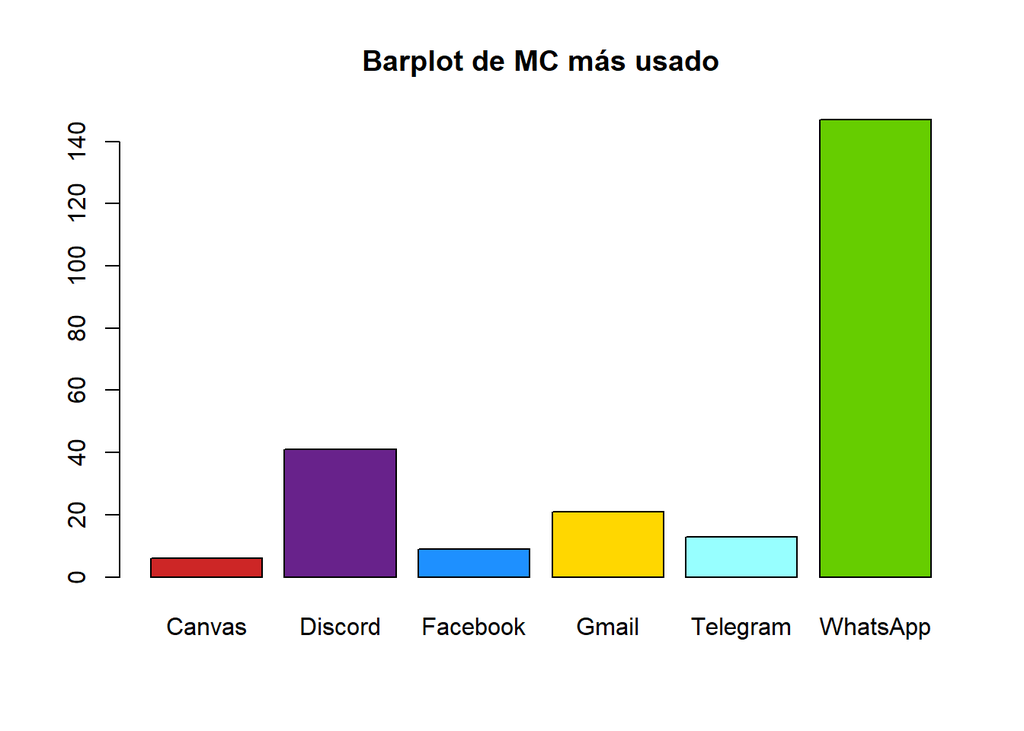

```r
barplot(table(DFinal$MaxMC)
        , col=c("firebrick3", "darkorchid4", "dodgerblue", "gold1", "darkslategray1", "chartreuse3")
        )
title("Barplot de MC más usado")
```

- Verificamos nuestro barplot con la moda:

```r
ModaCreada(DFinal$MaxMC)
```

```
## [1] "WhatsApp"
```

- Se realizará un barplot con el fin de identificar el medio de comunicación con el que se sienten más cómodos.

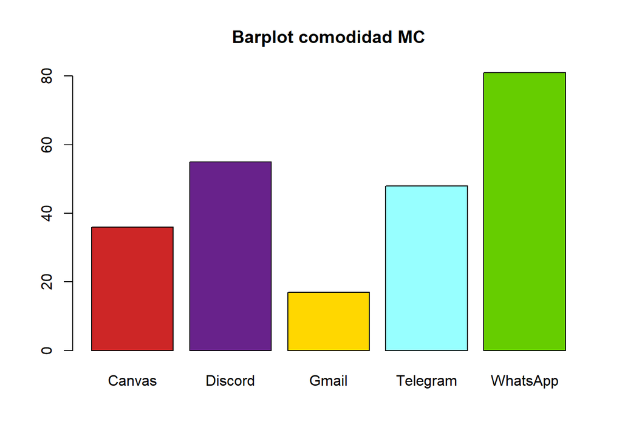

```r
barplot(table(DFinal$ComodidadMC)
        , col=c("firebrick3", "darkorchid4", "gold1", "darkslategray1", "chartreuse3")
        )
title("Barplot comodidad MC")
```

- Verificamos nuestro barplot con la moda:

```r
ModaCreada(DFinal$ComodidadMC)
```

```
## [1] "WhatsApp"
```

- Se realizará un barplot con el fin de identificar el medio de comunicación con el que sientan que más lo dominan.

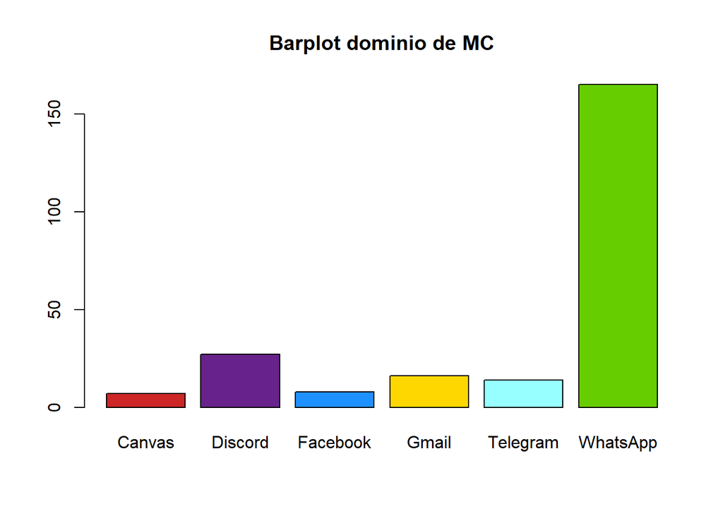

```r
barplot(table(DFinal$MasDominioMC)
        , col=c("firebrick3", "darkorchid4", "dodgerblue", "gold1", "darkslategray1", "chartreuse3")
        )
title("Barplot dominio de MC")
```

- Verificamos nuestro barplot con la moda:

```r
ModaCreada(DFinal$MasDominioMC)
```

```
## [1] "WhatsApp"
```

Se eligió relacionar el promedio ponderado (de los que tienen más de 15) con el tiempo de WhatsApp para verificar el rendimiento académico con respecto al uso de este medio, que es el más popular.

```r
n2<-nrow(DFA)
media2<-mean(DFA$TiempoMCW)
desv2<-sd(DFA$TiempoMCW)
error.est2<-desv2/sqrt(n2)
margen.error2<-qnorm(1-alfa.2, 0, 1)*error.est2
margen.error2
```

```
## [1] 0.3288942
```

Hallando los límites del intervalo de confianza:

```r
lim.inf2<-media2-margen.error2
lim.inf2
```

```
## [1] 4.146414
```

```r
lim.sup2<-media2+margen.error2
lim.sup2
```

```
## [1] 4.804203
```

Se creó un histograma del promedio del tiempo en WhatsApp de los estudiantes que tienen un promedio mayor a 15.

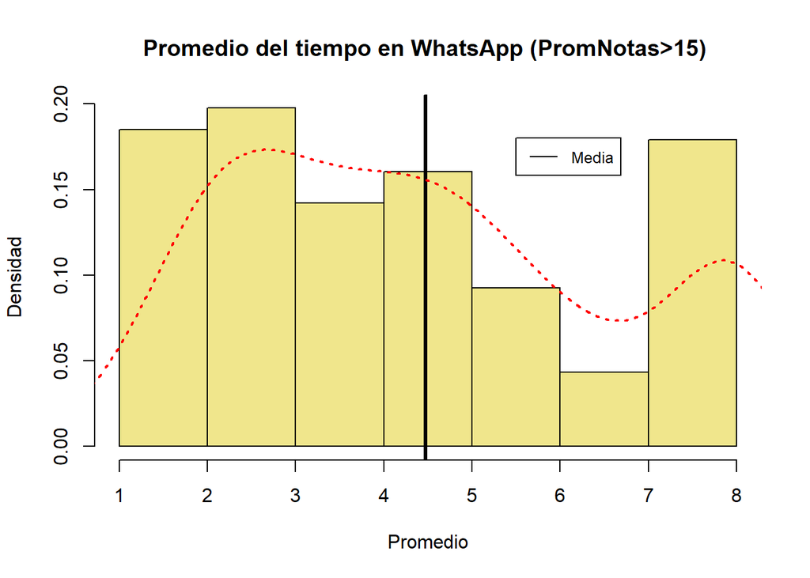

```r
# Generate the plot
hist(DFA$TiempoMCW
     , breaks=9
     , freq = FALSE
     , main="Promedio del tiempo en WhatsApp (PromNotas>15) "
     , xlab="Promedio"
     , ylab = "Densidad"
     , col = "khaki")

abline(v = mean(DFA$TiempoMCW), col = "black",lwd = 3)

# Linea
lines(density(na.omit(DFA$TiempoMCW)), lty="dotted", lwd=2, col="red")
legend(5.5, 0.18, legend=c("Media"), col=c("black"), lty=1, cex=0.8)
```

**Observaciones de la variable TiempoMCW del DFA (promedio de notas mayores a 15):**

- Con respecto al histograma de promedio de tiempo en WhatsApp, podemos observar que los datos se concentran principalmente en el segundo intervalo [2-3]. Además, el área menos densa es la que pertenece al intervalo de [6-7].

Se eligió relacionar el promedio ponderado (de los que tienen menos de 15) con el tiempo de WhatsApp para verificar el rendimiento académico con respecto al uso de este medio, que es el más popular.

```r
n3<-nrow(DFB)
media3<-mean(DFB$TiempoMCW)
desv3<-sd(DFB$TiempoMCW)
error.est3<-desv3/sqrt(n3)
margen.error3<-qnorm(1-alfa.2, 0, 1)*error.est3
margen.error3
```

```
## [1] 0.494978
```

Hallando los límites del intervalo de confianza:

```r
lim.inf3<-media3-margen.error3
lim.inf3
```

```
## [1] 4.100144
```

```r
lim.sup3<-media3+margen.error3
lim.sup3
```

```
## [1] 5.0901
```

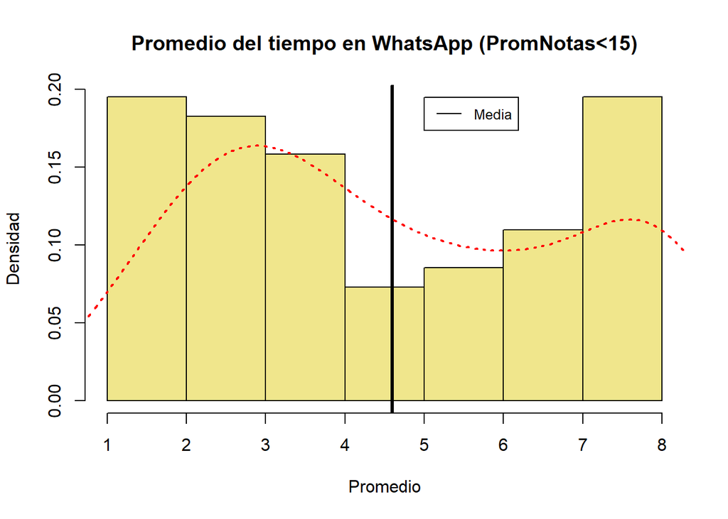

```r
# Generate the plot
hist(DFB$TiempoMCW
     , breaks=8
     , freq = FALSE
     , main="Promedio del tiempo en WhatsApp (PromNotas<15)"
     , xlab="Promedio" , ylab = "Densidad", col = "khaki")

abline(v = mean(DFB$TiempoMCW), col = "black",lwd = 3)

# Linea
lines(density(na.omit(DFB$TiempoMCW)), lty="dotted", lwd=2, col="red")
legend(5, 0.195, legend=c("Media"), col=c("Black"), lty=1, cex=0.8)
```

**Observaciones de la variable TiempoMCW del DFB (promedio de notas menores a 15):**

- Con respecto al histograma de promedio de tiempo en WhatsApp, podemos observar que, a diferencia del histograma anterior, los datos se concentran principalmente en el primer y último intervalo [1-2] y [7-8] respectivamente. Además, el área menos densa es la que encontramos en el intervalo de [4-5].

*Hipótesis*

**Prueba de Hipótesis 1**

```r
media1 <- mean(evil.DF.lee.anuncio$PromHorasMC)

zobservado1 <- (media - media1)/(desv/sqrt(n))
zcritico1 <- qnorm(alfa, lower.tail = TRUE)

zobservado1
```

```
## [1] -1.446303
```

```r
zcritico1
```

```
## [1] -1.644854
```

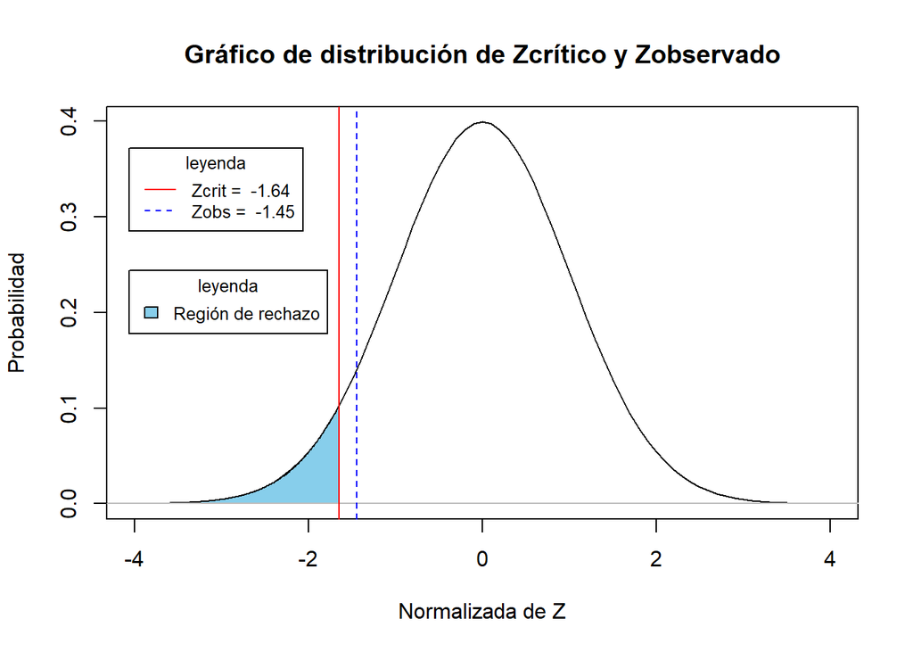

```r
Xs <-seq(-4, 4, by=0.1)
Xh1<-seq(-4, zcritico1, by=0.01)

plot(Xs
     , dnorm(Xs)
     , type="l"
     , xlab="Normalizada de Z"
     , ylab="Probabilidad")


xP <- c(-4,Xh1,zcritico1)
yP <- c(0,dnorm(Xh1,0,1),0)

polygon(xP,yP,col="skyblue")


abline(h = 0, col="gray")
abline(v = c(zcritico1, zobservado1)
       , lty=c(1, 2, 1)
       , col = c("red", "blue"))

legend(x="topleft", inset = c(0.030, 0.10)
       ,legend = c(paste("Zcrit = ", r(zcritico1)), paste("Zobs = ", r(zobservado1)))
       ,col=c("red","blue"),lty = 1:2,title ="leyenda",text.font = 4,cex = 0.8)

legend(x="bottomleft", inset = c(0.030, 0.450)
       ,legend = c("Región de rechazo"), col=c("lightblue"), title ="leyenda", text.font = 3,fill=c(col="skyblue"),cex=0.8)

title("Gráfico de distribución de Zcrítico y Zobservado")
```

Como $z_{observado}$ no cae en la región de rechazo
$$RR=\{x\in\mathbb R:
x<z_{critico}\}$$
, nos hace pensar que tenemos evidencia estadística suficiente para no rechazar la hipótesis nula. Pero necesitamos observar el p-value para obtener la significancia de la hipótesis.

```r
pvalor1 <- pnorm(zobservado1)
pvalor1
```

```
## [1] 0.07404614
```

El pvalor tiene una significancia de 0.07, la cual es mayor que 0.05. Por tal motivo, hay evidencia estadística suficiente como para no rechazar nuestra hipótesis nula.

**Prueba de Hipótesis 2:**

> $H_{o}$: El promedio de notas de las personas que juegan videojuegos y utilizan discord es menor igual que 15

> $H_{a}$: El promedio de notas de las personas que juegan videojuegos y utilizan discord es mayor que 15
- Calculamos el Zobservado y el Zcrítico. Realizamos una prueba de hipótesis unilateral con cola superior.

```r
zobservado4<-(media4-15)/(desv4/sqrt(n4))
zcritico4<-qnorm(1-alfa,lower.tail = TRUE)
zobservado4
```

```
## [1] 5.932779
```

```r
zcritico4
```

```
## [1] 1.644854
```

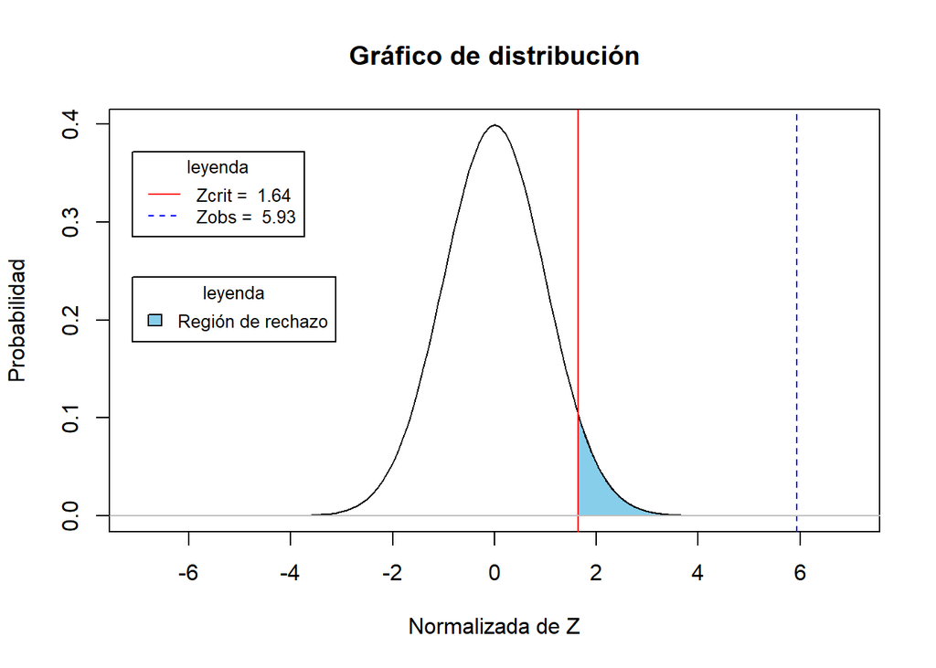

```r
Xs4<-seq(-7, 7,by=0.1)
Xh2<-seq(zcritico4,10, by=0.01)

plot(Xs4,dnorm(Xs4),type="l", xlab = "Normalizada de Z", ylab = "Probabilidad")

xP2 <- c(zcritico4,Xh2,10)
yP2 <- c(0,dnorm(Xh2,0,1),0)

polygon(xP2,yP2,col="skyblue")

abline(v=c(zcritico4, zobservado4)
       ,lty = c(1,2, 1)
       ,col=c("red","blue"))

abline(h=0,col="gray")

legend(x="topleft", inset = c(0.030, 0.10)
       ,legend = c(paste("Zcrit = ", r(zcritico4)), paste("Zobs = ", r(zobservado4)))
       ,col=c("red","blue"),lty = 1:2,title ="leyenda",text.font = 4,cex = 0.8)

legend(x="bottomleft", inset = c(0.030, 0.450)
       ,legend = c("Región de rechazo"), col=c("lightblue"), title ="leyenda", text.font = 3,fill=c(col="skyblue"),cex=0.8)

title("Gráfico de distribución")
```

```r
pvalor4<-pnorm(zobservado4, lower.tail = FALSE)
pvalor4
```

```
## [1] 1.489251e-09
```

El pvalor tiene una significancia de 0.000000001489, la cual es menor que 0.05. Por tal motivo, se puede rechazar la hipótesis nula.

**Prueba de Hipótesis 3**

> $H_{o}$: El promedio de horas en Whatsapp de las personas con promedio menor que 15 es mayor o igual que el promedio de horas en Whatsapp de las personas con promedio mayor que 15

> $H_{a}$: El promedio de horas en Whatsapp de las personas con promedio menor que 15 es menor que el promedio de horas en Whatsapp de las personas con promedio mayor que 15

Realizamos una prueba de hipótesis unilateral con cola inferior.

```r
zobservado<-(media3-media2)/(desv3/sqrt(73))
zcritico<-qnorm(alfa,lower.tail = TRUE)
zobservado
```

```
## [1] 0.4476327
```

```r
zcritico
```

```
## [1] -1.644854
```

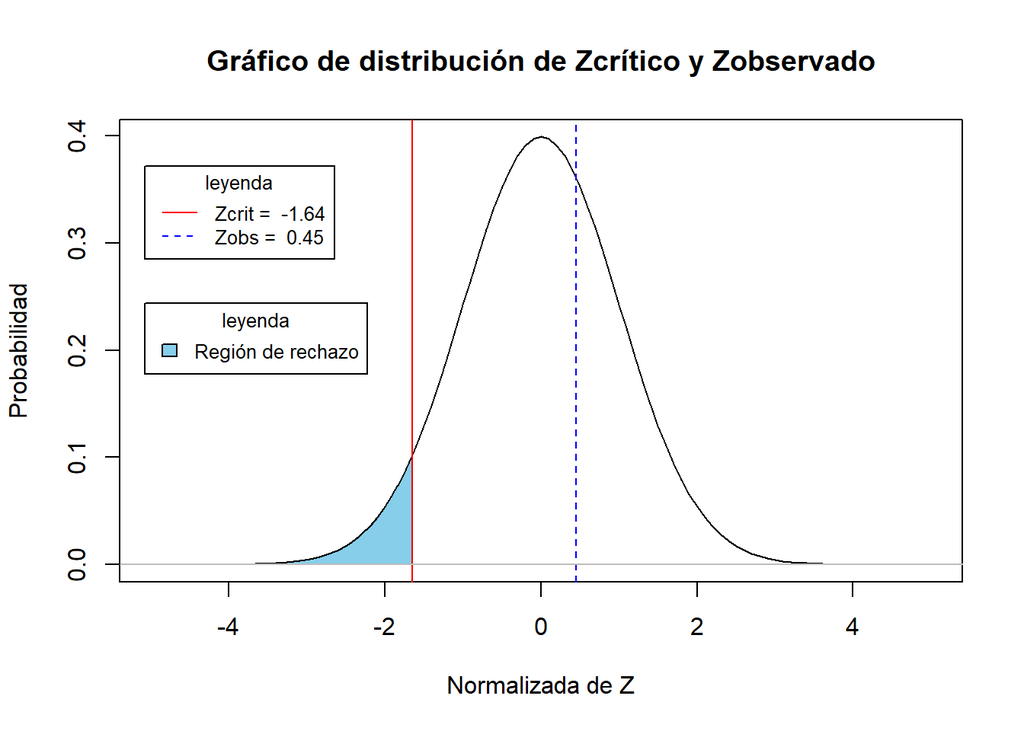

```r
Xs<-seq(-5,5,by=0.1)
Xh3<-seq(-4, zcritico, by=0.01)

plot(Xs,dnorm(Xs),type="l", xlab = "Normalizada de Z", ylab = "Probabilidad")


xP3 <- c(-4,Xh3,zcritico)
yP3 <- c(0,dnorm(Xh3,0,1),0)

polygon(xP3,yP3,col="skyblue")


abline(v = c(zcritico, zobservado), lty=c(1,2, 1), col=c("red","blue"))
abline(h = 0, col="gray")

legend(x="topleft", inset = c(0.030, 0.10)
       ,legend = c(paste("Zcrit = ", r(zcritico)), paste("Zobs = ", r(zobservado)))
       ,col=c("red","blue"),lty = 1:2,title ="leyenda",text.font = 4,cex = 0.8)

legend(x="bottomleft", inset = c(0.030, 0.450)
       ,legend = c("Región de rechazo"),col=c("lightblue"),title ="leyenda",text.font = 3,fill=c(col="skyblue"),cex=0.8)

title("Gráfico de distribución de Zcrítico y Zobservado")
```

Como $z_{observado}$ no cae en la región de rechazo
$$RR=\{x\in\mathbb R:
x<z_{critico}\}$$
, nos hace pensar que podemos no rechazar la hipótesis nula. Pero necesitamos ver el p-value para saber la significancia de la hipótesis.

```r
pvalor<-pnorm(zobservado)
pvalor
```

```
## [1] 0.6727908
```

El pvalor tiene una significancia de 0.67, la cual es mayor que 0.05. Por tal motivo, hay evidencia estadística suficiente como para no rechazar nuestra hipótesis nula.

**VII. Regresión:**

Con el fin de conocer mejor el comportamiento de la variable del promedio de horas que utilizan los medios de comunicación con respecto al promedio ponderado, realizaremos un gráfico de dispersión suavizado el cual permitirá analizar la naturaleza y concentración de estas variables.

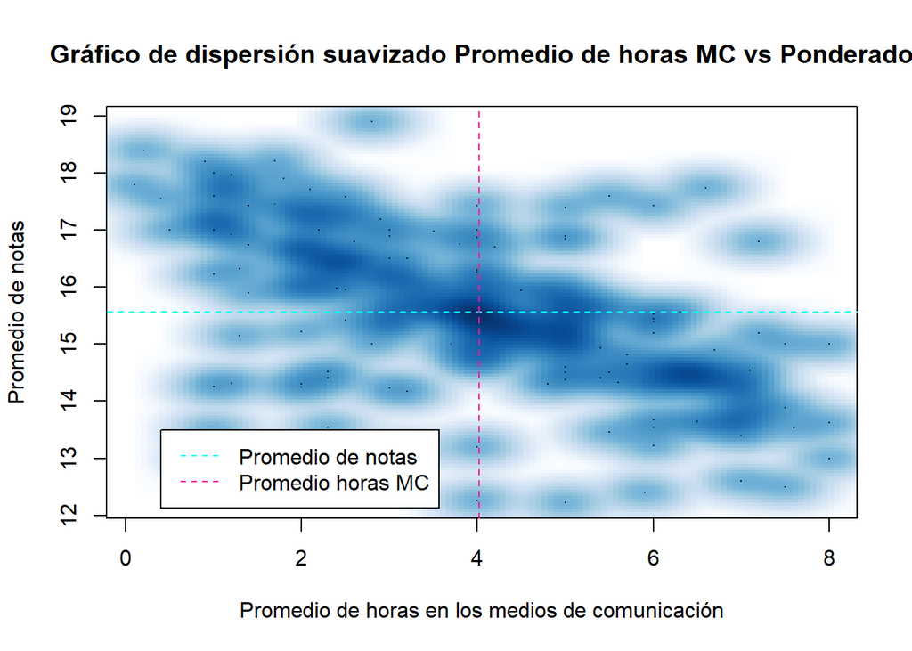

```r
Prom.Hrs.MC <- DFinal$PromHorasMC
Prom.Notas <-DFinal$PromNotas
smoothScatter(Prom.Hrs.MC, Prom.Notas,
              xlab="Promedio de horas en los medios de comunicación",
              ylab="Promedio de notas")

abline(h = mean(DFinal$PromNotas), lty = 2, col = "cyan")
abline(v = mean(DF$PromHorasMC)  , lty = 2, col = "deeppink")

title("Gráfico de dispersión suavizado Promedio de horas MC vs Ponderado")
legend(0.4, 13.5, c("Promedio de notas", "Promedio horas MC"), col = c("cyan", "deeppink"), lty = 2)
```

El gráfico simula un mapa en donde las zonas más oscuras representan una mayor concentración de los puntos. En nuestro caso, se evidencia una concentración que cae en la media de ambas variables.

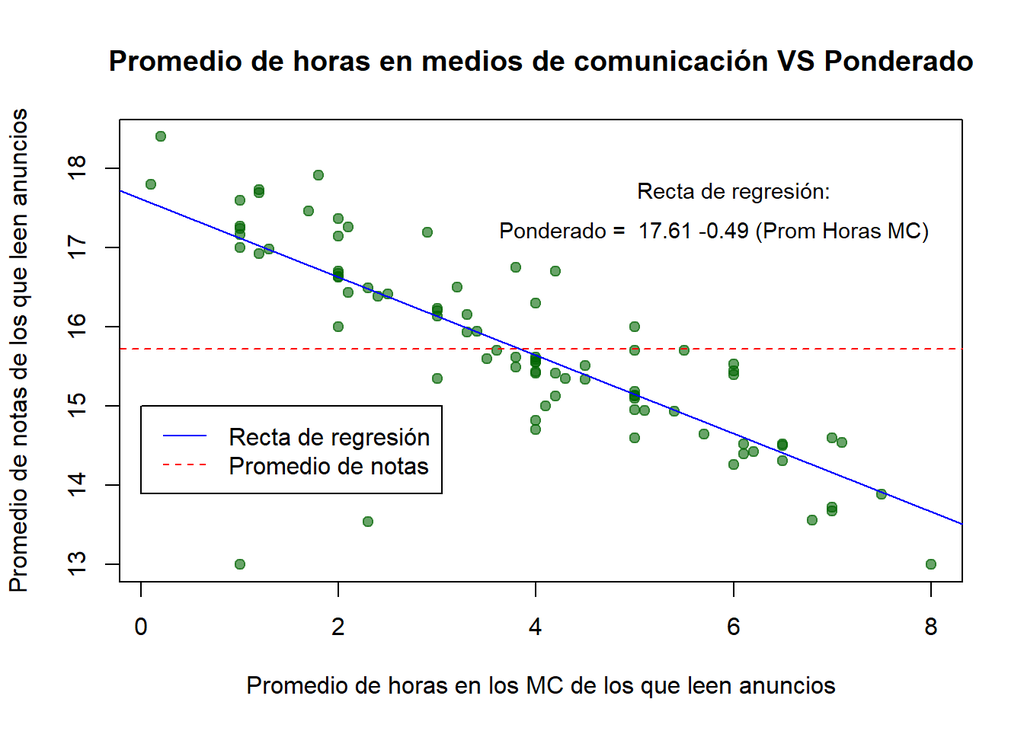

```r
regresion1 <- lm(PromNotas ~ PromHorasMC, data = DF.lee.anuncio)

plot(DF.lee.anuncio $PromHorasMC
     , DF.lee.anuncio $PromNotas
     , col=rgb(0,100,0,150, maxColorValue=255)
     , pch = 19
     , xlab="Promedio de horas en los MC de los que leen anuncios"
     , ylab="Promedio de notas de los que leen anuncios")

abline(regresion1, col="blue")
abline(h = mean(DF.lee.anuncio$PromNotas), col = "red", lty = 2)

text(6, 17.7, "Recta de regresión:", cex = 0.9)
text(5.8
     , 17.2
     , paste("Ponderado = "
             ,r(regresion1$coefficients[1])
             ,r(regresion1$coefficients[2])
             ,"(Prom Horas MC)")
     , cex = 0.9)

title("Promedio de horas en medios de comunicación VS Ponderado")
legend(0, 15, c("Recta de regresión", "Promedio de notas"), col = c("blue", "red"), lty = 1:2)
```

```r
summary(regresion1)
```

```
##
## Call:
## lm(formula = PromNotas ~ PromHorasMC, data = DF.lee.anuncio)
##
## Residuals:
##     Min      1Q  Median      3Q     Max
## -4.1204 -0.1486 -0.0099  0.3830  1.1847
##
## Coefficients:
##             Estimate Std. Error t value Pr(>|t|)
## (Intercept) 17.61423    0.17550  100.36   <2e-16 ***
## PromHorasMC -0.49387    0.04105  -12.03   <2e-16 ***
## ---
## Signif. codes:  0 '***' 0.001 '**' 0.01 '*' 0.05 '.' 0.1 ' ' 1
##
## Residual standard error: 0.7269 on 84 degrees of freedom
## Multiple R-squared:  0.6328, Adjusted R-squared:  0.6285
## F-statistic: 144.8 on 1 and 84 DF,  p-value: < 2.2e-16
```

Interpretación del gráfico de regresión: Se optó utilizar un gráfico de regresión lineal, dado que se consideró que existiría una relación entre las horas que pasan los alumnos en los medios de comunicación y sus ponderados de ciclo. Se puede ver que el coeficiente de determinación es de 0.6285, lo cuál indica que el modelo lineal ayuda a explicar la variabilidad de la variable dependiente en un 62.85%. Además, en la validación de significancia de los coeficientes, estos resultan significativos puesto que el p valor de ambos es mucho menor a 0.05. Finalmente, nuestro modelo tiene p valor menor a 0.05, por lo que nuestra regresión es significativa.

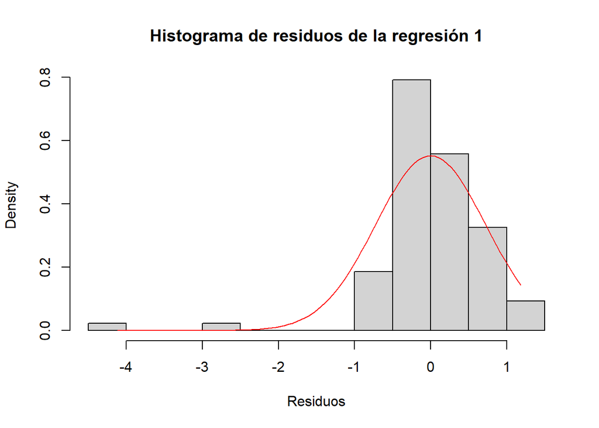

```r
hist(regresion1$residuals, breaks=8, probability = T, main = "Histograma de residuos de la regresión 1",
     xlab= "Residuos")

xa <- seq(min(regresion1$residuals), max(regresion1$residuals),length=100)
fa <- dnorm(xa, mean = mean(regresion1$residuals), sd=sd(regresion1$residuals))

lines(xa,fa,col="red")
```

A pesar de poseer una campana, estos residuos no se adecuan completamente a una distribución normal. Esto principalmente debido a que una característica de la distribución normal es que debe ser estrictamente simétrica.

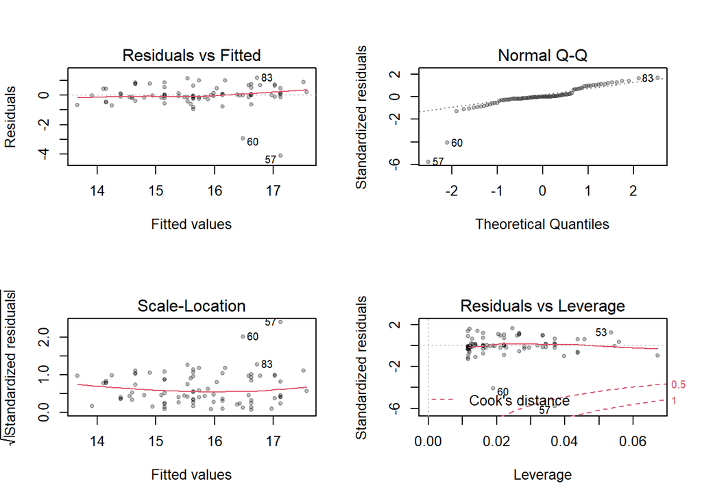

```r
op <- par(regresion1, mfrow=c(2,2))
plot(regresion1, pch=20, col=rgb(0,0,0,0.25))
```

En la normal Q-Q no se considera normal la distribución de los cuantiles, puesto que presenta algunos datos que forman una cola.

Análisis de la primera regresión: los alumnos a pesar de leer los anuncios a tiempo, tienden a sacar menor nota si pasan demasiado tiempo en los medios de comunicación (con una pendiente de -0.49). Pese a ello, esta interpretación tiene el sesgo de que el tiempo en los medios de comunicación se reparta en diferentes actividades como: ocio, estudio, diversión, etc. Por ello, se puede afirmar que el conglomerado de estas actividades afectan el rendimiento universitario y, si los estudiantes pasan demasiado tiempo en los medios de comunicación, puede verse perjudicados.

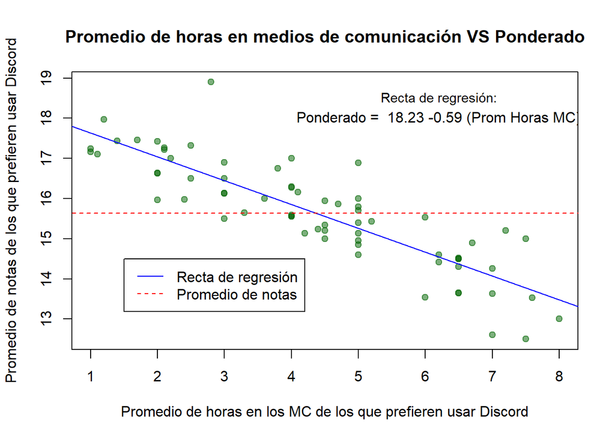

```r
DF.Discord <- filter(DFSJV, MaxMC=="Discord" | Max2MC=="Discord")
regresion2 <- lm(PromNotas ~ PromHorasMC, data = DF.Discord)

plot(DF.Discord$PromHorasMC, DF.Discord$PromNotas
     , col= rgb(0, 100, 0, 130, maxColorValue=255)
     , pch = 19
     , xlab="Promedio de horas en los MC de los que prefieren usar Discord"
     , ylab="Promedio de notas de los que prefieren usar Discord")

abline(regresion2, col="blue")
abline(h = mean(DF.Discord$PromNotas), lty = 2, col = "red")

text(6.2, 18.5, "Recta de regresión:", cex = 0.9)
text(6.2
     , 18
     , paste("Ponderado = "
             ,r(regresion2$coefficients[1])
             ,r(regresion2$coefficients[2])
             ,"(Prom Horas MC)")
     , cex = 01)

title("Promedio de horas en medios de comunicación VS Ponderado")
legend(1.5, 14.5, c("Recta de regresión", "Promedio de notas"), col = c("blue", "red"), lty = c(1,2))
```

```r
summary(regresion2)
```

```
##
## Call:
## lm(formula = PromNotas ~ PromHorasMC, data = DF.Discord)
##
## Residuals:
##      Min       1Q   Median       3Q      Max
## -1.46738 -0.40721 -0.07662  0.39460  2.33579
##
## Coefficients:
##             Estimate Std. Error t value Pr(>|t|)
## (Intercept) 18.22876    0.20606   88.46   <2e-16 ***
## PromHorasMC -0.59448    0.04339  -13.70   <2e-16 ***
## ---
## Signif. codes:  0 '***' 0.001 '**' 0.01 '*' 0.05 '.' 0.1 ' ' 1
##
## Residual standard error: 0.6772 on 66 degrees of freedom
## Multiple R-squared:  0.7399, Adjusted R-squared:  0.736
## F-statistic: 187.7 on 1 and 66 DF,  p-value: < 2.2e-16
```

Interpretación del gráfico de regresión: Se utilizó un gráfico de regresión lineal, pues consideramos que podría existir una relación entre las horas que pasan los estudiantes que usan Discord en los medios de comunicación y el rendimiento académico a lo largo del ciclo. El coeficiente de determinación es de 0.736, este valor sugiere que nuestro ajuste es de relativa calidad, ya que puede explicar el 73.6% de la variabilidad de la variable dependiente. Además, en la validación de significancia de los coeficientes, estos resultan significativos puesto que el p valor de ambos es mucho menor a 0.05. Finalmente, nuestro modelo tiene p valor menor a 0.05, por lo que nuestra regresión es significativa.

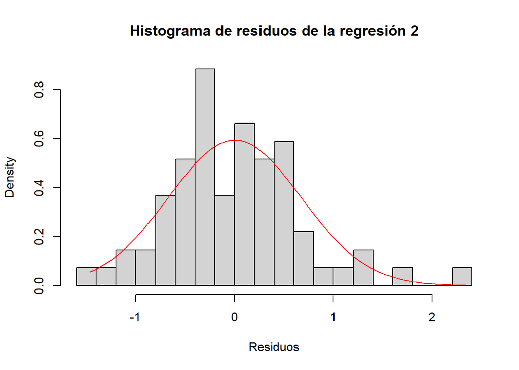

```r
hist(regresion2$residuals, breaks=15, probability = T, main = "Histograma de residuos de la regresión 2", xlab= "Residuos")
xa2 <- seq(min(regresion2$residuals), max(regresion2$residuals),length=100)
fa2 <- dnorm(xa2, mean = mean(regresion2$residuals), sd=sd(regresion2$residuals))

lines(xa2, fa2, col="red")
```

La distribución de residuales se aproxima un poco mejor al de la regresión anterior. Sin embargo, parece existir un valor que empobrece la simetría de una distribución normal.

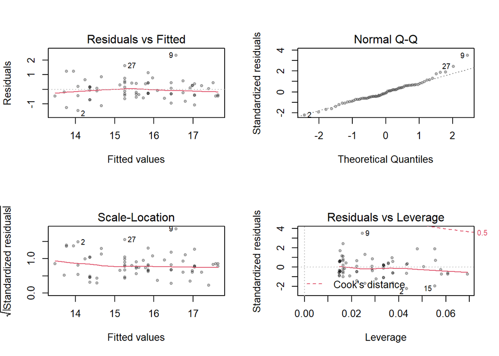

```r
op <- par(regresion2, mfrow=c(2,2))
plot(regresion2, pch=20, col=rgb(0,0,0,0.25))
```

En la normal Q-Q no se considera normal la distribución de los cuantiles, puesto que presenta algunos datos que forman una cola en la parte superior.

```r
f <- function(x) {
  18.23 - 0.59*x
}
```

Estimamos los promedios de alumnos con las características descritas anteriormente de 9, 10 horas de uso diario de medios de comunicación

```r
f(9)
```

```
## [1] 12.92
```

```r
f(10)
```

```
## [1] 12.33
```

Podemos apreciar que en nuestro modelo de ajuste lineal, la naturaleza de la recta indica que conforme más horas se invierten en medios de comunicación el promedio ponderado del alumno tiende a disminuir.

**Bibliografía**

> Ramírez-Alán, O. (09 de octubre de 2017). Correlación y Regresión Lineal. RPubs. https://rpubs.com/osoramirez/316691